# Part 2 of project

Author

Akhil Penumudy

Modified

March 3, 2025

# **(1) Codebook/Datasheet:**

## Background

The goal of this project is to analyze the relationship between a **song’s audio features** (e.g., danceability, energy, valence, tempo) and its **popularity**, as measured by Spotify streams and YouTube views. Additionally, the project will explore how YouTube engagement metrics (e.g., likes, comments, official video status) and other factors (e.g., album type, licensed status) contribute to a song’s popularity. Through exploratory data analysis, this project aims to identify key trends, correlations, and potential predictors of song popularity, providing insights into what makes a song successful across platforms.

## About the data set

This data set consists of:

- Several statistics for the Top 10 songs of various spotify artists and their youtube video.
- It includes 26 variables for each of the songs collected from spotify and youtube
- Sourced from 7th of February, 2023

## Variables and descriptions

```r
raw_spotify_df <- read.csv('Spotify_Youtube.csv')
colnames(raw_spotify_df)
```

```
 [1] "X"                "Artist"           "Url_spotify"      "Track"
 [5] "Album"            "Album_type"       "Uri"              "Danceability"
 [9] "Energy"           "Key"              "Loudness"         "Speechiness"
[13] "Acousticness"     "Instrumentalness" "Liveness"         "Valence"
[17] "Tempo"            "Duration_ms"      "Url_youtube"      "Title"
[21] "Channel"          "Views"            "Likes"            "Comments"
[25] "Description"      "Licensed"         "official_video"   "Stream"
```

```r
# Check the dimensions of the dataset (rows, columns)
dim(raw_spotify_df)
```

```
[1] 20718    28
```

### What do the variables mean?

| Variable | Description |
| --- | --- |
| **Track** | The name of the song as displayed on Spotify. |
| **Artist** | The name of the artist who performed the song. |
| **Url_spotify** | The URL link to the song on Spotify. |
| **Album** | The album in which the song is contained on Spotify. |
| **Album_type** | Indicates whether the song was released as a single or is part of an album. |
| **Uri** | A Spotify URI used to locate the song via the Spotify API. |
| **Danceability** | A measure of how suitable the track is for dancing, based on tempo, rhythm stability, beat strength, and regularity. Ranges from 0.0 (least danceable) to 1.0 (most danceable). |
| **Energy** | A measure of the track’s intensity and activity, ranging from 0.0 to 1.0. High-energy tracks feel fast, loud, and noisy, while low-energy tracks are calmer and softer. |
| **Key** | The key of the track, represented as an integer using standard Pitch Class notation (e.g., 0 = C, 1 = C♯/D♭, 2 = D). A value of -1 indicates no key was detected. |
| **Loudness** | The average loudness of the track in decibels (dB), typically ranging from -60 to 0 dB. Higher values indicate louder tracks. |
| **Speechiness** | Detects the presence of spoken words in the track. Values above 0.66 indicate mostly spoken content, while values below 0.33 likely represent music or non-speech content. |
| **Acousticness** | A confidence measure (0.0 to 1.0) of whether the track is acoustic. A value of 1.0 indicates high confidence the track is acoustic. |
| **Instrumentalness** | Predicts whether the track contains no vocals. Values closer to 1.0 indicate a higher likelihood of no vocal content. |
| **Liveness** | Detects the presence of an audience in the recording. Values above 0.8 suggest a strong likelihood the track was performed live. |
| **Valence** | A measure of the track’s musical positiveness, ranging from 0.0 (negative emotions like sadness or anger) to 1.0 (positive emotions like happiness or euphoria). |
| **Tempo** | The estimated tempo of the track in beats per minute (BPM). |
| **Duration_ms** | The duration of the track in milliseconds. |
| **Stream** | The number of streams the song has on Spotify. |
| **Url_youtube** | The URL of the YouTube video linked to the song, if available. |
| **Title** | The title of the YouTube video. |
| **Channel** | The name of the YouTube channel that published the video. |
| **Views** | The number of views the YouTube video has received. |
| **Likes** | The number of likes the YouTube video has received. |
| **Comments** | The number of comments on the YouTube video. |
| **Description** | The description of the YouTube video. |
| **Licensed** | Indicates whether the video represents licensed content, meaning it was uploaded by a YouTube content partner and claimed by them. |
| **official_video** | A boolean value indicating whether the video is the official video for the song. |

# **(2) Summary Statistics**

```r
#this function just gives us the first few rows of the dataset
head(raw_spotify_df)
```

```
  X   Artist                                            Url_spotify
1 0 Gorillaz https://open.spotify.com/artist/3AA28KZvwAUcZuOKwyblJQ
2 1 Gorillaz https://open.spotify.com/artist/3AA28KZvwAUcZuOKwyblJQ
3 2 Gorillaz https://open.spotify.com/artist/3AA28KZvwAUcZuOKwyblJQ
4 3 Gorillaz https://open.spotify.com/artist/3AA28KZvwAUcZuOKwyblJQ
5 4 Gorillaz https://open.spotify.com/artist/3AA28KZvwAUcZuOKwyblJQ
6 5 Gorillaz https://open.spotify.com/artist/3AA28KZvwAUcZuOKwyblJQ
                                          Track
1                                Feel Good Inc.
2                               Rhinestone Eyes
3 New Gold (feat. Tame Impala and Bootie Brown)
4                            On Melancholy Hill
5                                Clint Eastwood
6                                          DARE
                                          Album Album_type
```

[output cut: 55 more lines]

```r
# This function gives us the  summary statistics for numerical columns
summary(raw_spotify_df)
```

```
       X            Artist          Url_spotify           Track
 Min.   :    0   Length:20718       Length:20718       Length:20718
 1st Qu.: 5179   Class :character   Class :character   Class :character
 Median :10358   Mode  :character   Mode  :character   Mode  :character
 Mean   :10358
 3rd Qu.:15538
 Max.   :20717

    Album            Album_type            Uri             Danceability
 Length:20718       Length:20718       Length:20718       Min.   :0.0000
 Class :character   Class :character   Class :character   1st Qu.:0.5180
 Mode  :character   Mode  :character   Mode  :character   Median :0.6370
                                                          Mean   :0.6198
                                                          3rd Qu.:0.7402
                                                          Max.   :0.9750
                                                          NA's   :2
     Energy               Key          Loudness        Speechiness
 Min.   :0.0000203   Min.   : 0.0   Min.   :-46.251   Min.   :0.00000
 1st Qu.:0.5070000   1st Qu.: 2.0   1st Qu.: -8.858   1st Qu.:0.03570
 Median :0.6660000   Median : 5.0   Median : -6.536   Median :0.05050
 Mean   :0.6352503   Mean   : 5.3   Mean   : -7.672   Mean   :0.09646
 3rd Qu.:0.7980000   3rd Qu.: 8.0   3rd Qu.: -4.931   3rd Qu.:0.10300
 Max.   :1.0000000   Max.   :11.0   Max.   :  0.920   Max.   :0.96400
 NA's   :2           NA's   :2      NA's   :2         NA's   :2
  Acousticness       Instrumentalness       Liveness         Valence
 Min.   :0.0000011   Min.   :0.0000000   Min.   :0.0145   Min.   :0.0000
 1st Qu.:0.0452000   1st Qu.:0.0000000   1st Qu.:0.0941   1st Qu.:0.3390
 Median :0.1930000   Median :0.0000024   Median :0.1250   Median :0.5370
 Mean   :0.2915353   Mean   :0.0559616   Mean   :0.1935   Mean   :0.5299
 3rd Qu.:0.4772500   3rd Qu.:0.0004630   3rd Qu.:0.2370   3rd Qu.:0.7262
 Max.   :0.9960000   Max.   :1.0000000   Max.   :1.0000   Max.   :0.9930
 NA's   :2           NA's   :2           NA's   :2        NA's   :2
     Tempo        Duration_ms      Url_youtube           Title
 Min.   :  0.0   Min.   :  30985   Length:20718       Length:20718
 1st Qu.: 97.0   1st Qu.: 180010   Class :character   Class :character
 Median :120.0   Median : 213284   Mode  :character   Mode  :character
 Mean   :120.6   Mean   : 224718
 3rd Qu.:139.9   3rd Qu.: 252443
 Max.   :243.4   Max.   :4676058
 NA's   :2       NA's   :2
   Channel              Views               Likes             Comments
 Length:20718       Min.   :0.000e+00   Min.   :       0   Min.   :       0
 Class :character   1st Qu.:1.826e+06   1st Qu.:   21581   1st Qu.:     509
 Mode  :character   Median :1.450e+07   Median :  124481   Median :    3277
                    Mean   :9.394e+07   Mean   :  663341   Mean   :   27519
                    3rd Qu.:7.040e+07   3rd Qu.:  522148   3rd Qu.:   14360
                    Max.   :8.080e+09   Max.   :50788652   Max.   :16083138
                    NA's   :470         NA's   :541        NA's   :569
 Description          Licensed         official_video         Stream
 Length:20718       Length:20718       Length:20718       Min.   :6.574e+03
 Class :character   Class :character   Class :character   1st Qu.:1.767e+07
 Mode  :character   Mode  :character   Mode  :character   Median :4.968e+07
                                                          Mean   :1.359e+08
                                                          3rd Qu.:1.384e+08
                                                          Max.   :3.387e+09
                                                          NA's   :576
```

# **(3) Data Investigation/Question of Interest**

## Question of Interest:

> *Can we predict the popularity of a song (measured by Spotify streams, YouTube views and a couple other factors) based on its audio features (e.g., danceability, energy, valence)?*

**Hypotheses**:

1. **Audio Features**:
   - Songs with higher **valence** (positive/happy tone) will be more popular.
   - Songs with higher **danceability** and **energy** will have more streams and views.
   - Songs with a moderate **tempo** (neither too fast nor too slow) will be more popular.
2. **YouTube Engagement**:
   - Songs with **official videos** will have significantly more views and streams.
   - Higher **likes** and **comments** on YouTube will correlate with higher Spotify streams.
3. **Other Features**:
   - **Singles** will have more streams and views compared to songs released as part of an album.
   - **Licensed content** will perform better due to higher visibility and promotion.

**What I Expect to Find**:  
I expect that a combination of audio features (e.g., danceability, energy) and YouTube engagement metrics (e.g., likes, official video status) will be strong predictors of a song’s popularity. Specifically, I anticipate that songs with high danceability, energy, and positive valence, along with strong YouTube engagement, will be the most popular.

# **(4) Processing**

## Data Cleaning

Check for missing values and decide how to handle them (e.g., remove rows, impute values)

```r
# Check for missing values in each column
colSums(is.na(raw_spotify_df))
```

```
               X           Artist      Url_spotify            Track
               0                0                0                0
           Album       Album_type              Uri     Danceability
               0                0                0                2
          Energy              Key         Loudness      Speechiness
               2                2                2                2
    Acousticness Instrumentalness         Liveness          Valence
               2                2                2                2
           Tempo      Duration_ms      Url_youtube            Title
               2                2                0                0
         Channel            Views            Likes         Comments
               0              470              541              569
     Description         Licensed   official_video           Stream
               0                0                0              576
```

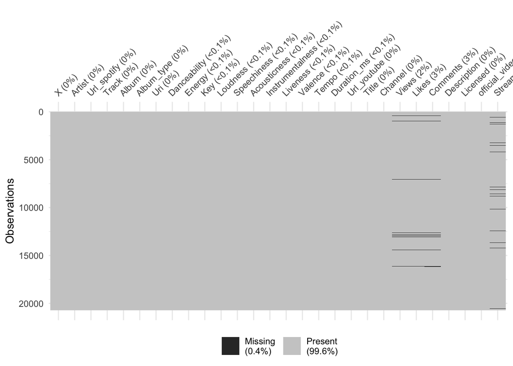

```r
# Visualize missing values
library(visdat)
vis_miss(raw_spotify_df)
```

```r
clean_spotify_df <- na.omit(raw_spotify_df)
```

## Load Libraries

```r
# Ensure all necessary libraries are loaded
library(ggplot2)
library(corrplot)
library(dplyr)
library(patchwork)
library(explore)
library(tidyr)
library(broom) # Useful for tidying model output
library(cluster) # For silhouette method in clustering
```

## Distribution of Key Variables

lets start by visualizing the distribution of the features that are a good metric to show off popularity.

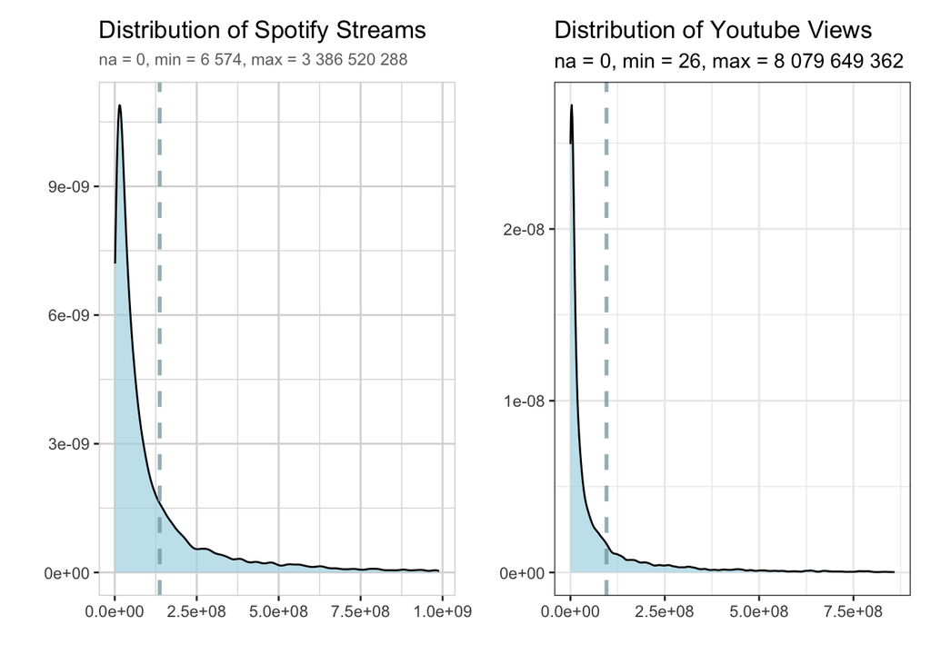

```r
# Plot 1: Distribution of Spotify Streams
plot1 <- clean_spotify_df %>% explore(Stream)
plot1 <-plot1 + labs(title = "Distribution of Spotify Streams")

# Plot 2: Distribution of YouTube Views
plot2 <- clean_spotify_df %>% explore(Views)
plot2 <-plot2 + labs(title = "Distribution of Youtube Views") + theme_bw()

combined_plots <- (plot1 | plot2)
combined_plots
```

In order gain a better understanding of the metrics in our hypothesis statements we should also look into the distribution for those variables in the data set (valence, danceability, energy and tempo)

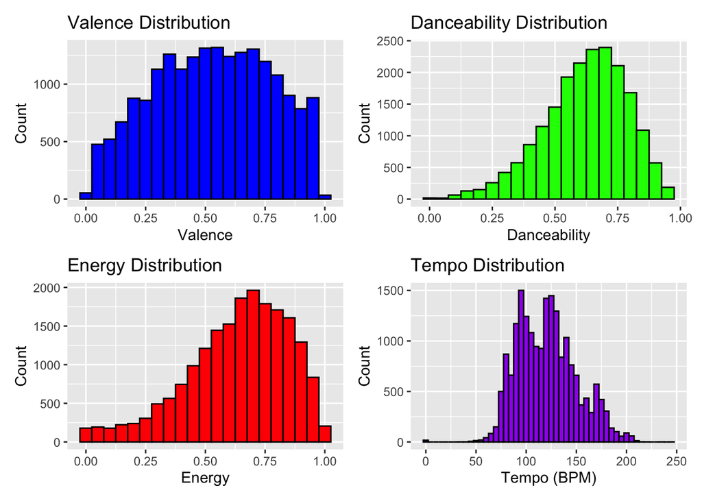

```r
# Create individual histograms
hist_valence <- ggplot(clean_spotify_df, aes(x = Valence)) +
  geom_histogram(binwidth = 0.05, fill = "blue", color = "black") +
  labs(title = "Valence Distribution", x = "Valence", y = "Count")

hist_danceability <- ggplot(clean_spotify_df, aes(x = Danceability)) +
  geom_histogram(binwidth = 0.05, fill = "green", color = "black") +
  labs(title = "Danceability Distribution", x = "Danceability", y = "Count")

hist_energy <- ggplot(clean_spotify_df, aes(x = Energy)) +
  geom_histogram(binwidth = 0.05, fill = "red", color = "black") +
  labs(title = "Energy Distribution", x = "Energy", y = "Count")

hist_tempo <- ggplot(clean_spotify_df, aes(x = Tempo)) +
  geom_histogram(binwidth = 5, fill = "purple", color = "black") +
  labs(title = "Tempo Distribution", x = "Tempo (BPM)", y = "Count")

# Combine the histograms into a single figure using patchwork
combined_histograms <- hist_valence + hist_danceability + hist_energy + hist_tempo

# Display the combined figure
combined_histograms
```

Through this figure we can see that most songs fall within a valence range of 0.339 to 0.726, as indicated by the 25th and 75th percentiles. Essentially, this means the majority of songs lean towards a “positive” and “happy” vibe, with higher valence values approaching 1. However, the data doesn’t show a strong concentration of valence values around any particular point.  
The majority of songs in this dataset exhibit energy and danceability levels around 0.68, indicating that most tracks are characterized by strong energy and are relatively danceable.

Apart from the metrics regarding the songs itself its also a good idea to understand the distribution for values in regard to the actual streaming services (YouTube likes and comments). In order to make a box plot for these variables we need to take advantage of the `pivot_longer()` function from the `tidyr` package which is used to **reshape data from wide to long format**.

- In a **wide format**, each variable has its own column (In this case `Likes` and `Comments` are separate columns which makes it wide).
- In a **long format**, multiple columns are combined into key-value pairs, making the data easier to work with for certain types of analysis or visualization.

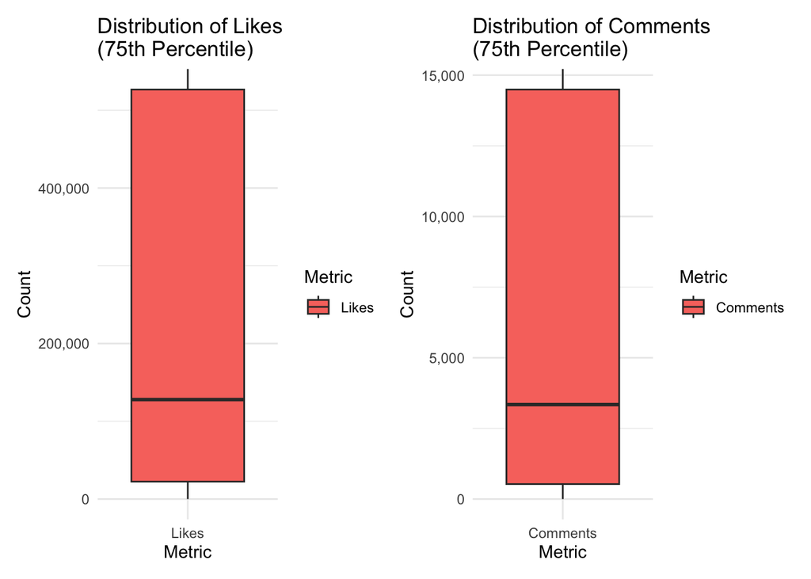

```r
# Reshape the data for Likes and Comments into a long format
clean_spotify_df_long <- clean_spotify_df %>%
  pivot_longer(cols = c(Likes, Comments), names_to = "Metric", values_to = "Value")

# Calculate the 95th percentile for Likes and Comments
likes_75th <- quantile(clean_spotify_df$Likes, 0.75, na.rm = TRUE)
comments_75th <- quantile(clean_spotify_df$Comments, 0.75, na.rm = TRUE)

# Using ggplot i made individual box plots for Likes and Comments and zoomed into the 75th percentile due to the shear size of the dataset.
box_plot_likes <- ggplot(clean_spotify_df_long %>% filter(Metric == "Likes"), aes(x = Metric, y = Value, fill = Metric)) +
  geom_boxplot() +
  scale_y_continuous(labels = scales::comma) + # this formats the  y-axis labels for readability
  coord_cartesian(ylim = c(0, likes_75th)) + # this zooms into the 75th percentile
  labs(title = "Distribution of Likes \n(75th Percentile)",
       x = "Metric",
       y = "Count") +
  theme_minimal()

box_plot_comments <- ggplot(clean_spotify_df_long %>% filter(Metric == "Comments"), aes(x = Metric, y = Value, fill = Metric)) +
  geom_boxplot() +
  scale_y_continuous(labels = scales::comma) +
  coord_cartesian(ylim = c(0, comments_75th)) +
  labs(title = "Distribution of Comments \n(75th Percentile)",
       x = "Metric",
       y = "Count") +
  theme_minimal()

# Using the same library we can just combine these plots into one figure.
combined_box_plots <- box_plot_likes + box_plot_comments

# Display the combined figure
combined_box_plots
```

## Developing the Popularity Score

Now that we have a clear understanding of the dataset’s structure, the next step is to create a new variable that serves as a single metric for “popularity”, which is the key outcome we aim to predict using the numerical features.  
This feature will be called `popularity_score`. This feature will be a value between 0 -100 and will be based on the columns `Likes`, `Comments`, `Stream`, and `Views` .

*Step 1: Normalize the Columns*

Since `Likes`, `Comments`, `Stream`, and `Views` are on different scales, we need to normalize them to a common scale such as from 0 to 1. This ensures that no single metric dominates the score due to its larger magnitude.

For each column, use the following normalization formula:

$Normalized\hspace{0.1cm}Value= \frac{Value−Min}{Max−Min}$

```r
# Normalize the columns
normalize <- function(x) {
  (x - min(x, na.rm = TRUE)) / (max(x, na.rm = TRUE) - min(x, na.rm = TRUE))
}

clean_spotify_df <- clean_spotify_df %>%
  mutate(
    norm_views = normalize(Views),
    norm_likes = normalize(Likes),
    norm_streams = normalize(Stream),
    norm_comments = normalize(Comments)
  )
```

*Step 2: Assigning Weights and calculating the score*

Since there are four key values we need to determine how much should each metric contribute to the score. I decided to break up the weights like so:

- **Views**: 35% weight (since views are a strong indicator of popularity).
- **Streams**: 38% weight (Spotify streams play a huge role in how much traction an artist has, especially since more people use spotify to listen to music compared to YouTube).
- **Likes**: 16.5% weight (Engagement is important but not as much as views. Also “likes” don’t determine if a song is viral, songs with a lot of dislikes can also be popular too).
- **Comments**: 10.5% weight (comments are a weaker indicator of popularity compared to likes).

```r
# Calculate popularity score
clean_spotify_df <- clean_spotify_df %>%
  mutate(
    popularity_score = (norm_views * 0.35 + norm_likes * 0.165 + norm_streams * 0.38 + norm_comments * 0.105) * 100
  )
```

Since the normalized values are between 0 and 1, the resulting score will also be between 0 and 1. To scale it to 0–100, we would just multiply it by 100.

We will come back how this score will be used later in this project.

# **(5) Analysis (Part 2)**

## Correlation Analysis

Next, lets look into the correlations between the numerical features.

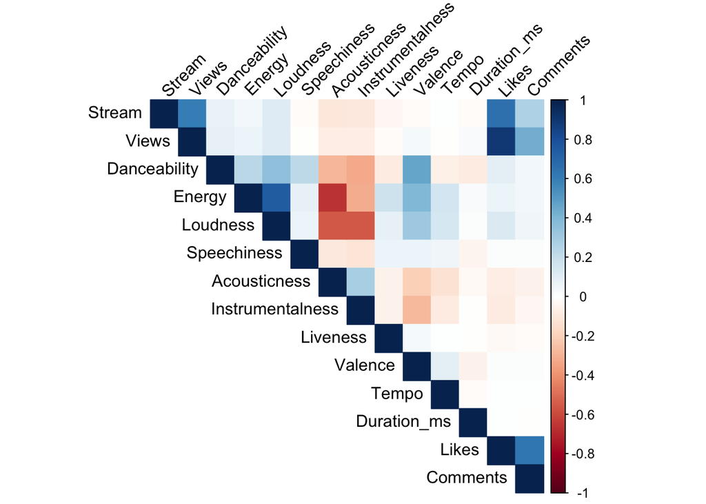

```r
# I am going to select all of the numerical columns for correlation analysis
numerical_df <- clean_spotify_df %>%
  select(Stream, Views, Danceability, Energy, Loudness, Speechiness, Acousticness, Instrumentalness, Liveness, Valence, Tempo, Duration_ms, Likes, Comments)

# Compute correlation matrix
cor_matrix <- cor(numerical_df, use = "complete.obs")

# Visualize correlation matrix
corrplot(cor_matrix, method = "color", type = "upper", tl.col = "black", tl.srt = 45)
```

**Takeaway:** Loudness and Energy appear to be the strongest correlates of popularity among the audio features based on this linear analysis. Acousticness shows a notable negative relationship. The strong correlations between the raw popularity metrics justify combining them into the `popularity_score`.

## Linear Regression: Predicting Popularity

Before making any type of regression we need to first check for the **distribution of the dependent variable (popularity_score):**

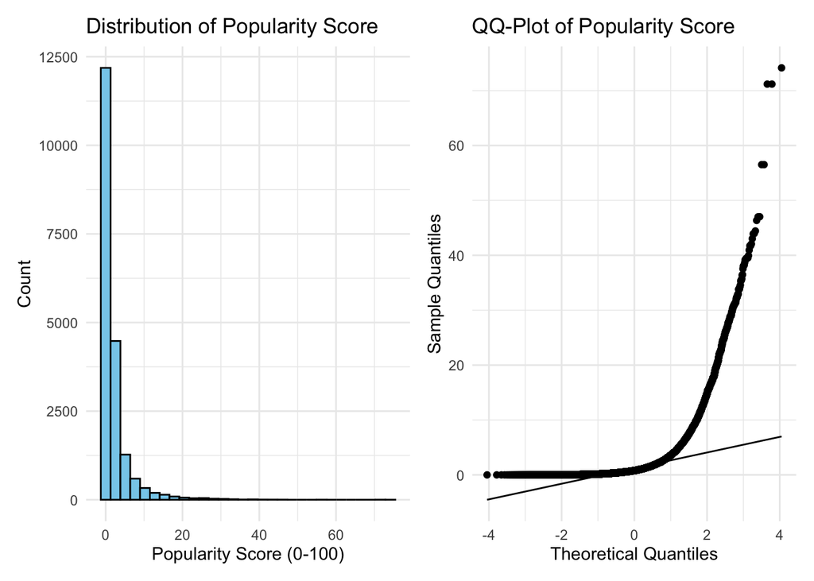

```r
# Histogram of popularity_score
hist_popularity <- ggplot(clean_spotify_df, aes(x = popularity_score)) +
  geom_histogram(bins = 30, fill = "skyblue", color = "black") +
  labs(title = "Distribution of Popularity Score", x = "Popularity Score (0-100)", y = "Count") +
  theme_minimal()

# QQ-plot for popularity_score
qq_popularity <- ggplot(clean_spotify_df, aes(sample = popularity_score)) +
  stat_qq() +
  stat_qq_line() +
  labs(title = "QQ-Plot of Popularity Score", x = "Theoretical Quantiles", y = "Sample Quantiles") +
  theme_minimal()

hist_popularity | qq_popularity
```

The plot on the right is known as a Q-Q (Quantile-Quantile) plot and gives us an idea of whether or not data set follows a certain theoretical distribution. In this case the `popularity_score` has a heavily right-skewed (most songs have low scores, a few have very high scores). This is expected given the distributions of Views and Stream. Standard linear regression might struggle with this. A transformation (like log or square root) of the popularity_score might be beneficial, or using models more robust to skewed data.

### Building the linear model

Let’s start with a model using core audio features identified as potentially relevant from the correlation analysis and hypotheses.

```r
lm_model1 <- lm(popularity_score ~ Danceability + Energy + Loudness + Speechiness + Acousticness + Instrumentalness + Liveness + Valence + Tempo, data = clean_spotify_df)
summary(lm_model1)
```

```
Call:
lm(formula = popularity_score ~ Danceability + Energy + Loudness +
    Speechiness + Acousticness + Instrumentalness + Liveness +
    Valence + Tempo, data = clean_spotify_df)

Residuals:
   Min     1Q Median     3Q    Max
-3.694 -1.914 -1.179  0.182 71.626

Coefficients:
                   Estimate Std. Error t value Pr(>|t|)
(Intercept)       4.6542807  0.3128097  14.879  < 2e-16 ***
Danceability      1.4247543  0.2238982   6.363 2.02e-10 ***
Energy           -1.8499446  0.2542137  -7.277 3.54e-13 ***
Loudness          0.1348613  0.0113779  11.853  < 2e-16 ***
Speechiness      -1.2159925  0.2867987  -4.240 2.25e-05 ***
Acousticness     -1.0997574  0.1415353  -7.770 8.22e-15 ***
Instrumentalness -0.4908150  0.1905159  -2.576 0.009995 **
Liveness         -0.6692408  0.1828931  -3.659 0.000254 ***
Valence          -0.8509150  0.1473056  -5.777 7.74e-09 ***
Tempo            -0.0008932  0.0010182  -0.877 0.380371
---
Signif. codes:  0 '***' 0.001 '**' 0.01 '*' 0.05 '.' 0.1 ' ' 1

Residual standard error: 4.091 on 19539 degrees of freedom
Multiple R-squared:  0.03023,   Adjusted R-squared:  0.02978
F-statistic: 67.68 on 9 and 19539 DF,  p-value: < 2.2e-16
```

**Conclusion on Linear Model:**

The standard linear model might not be the best at accurately predicting popularity. The R-squared is relatively low. While the coefficients give some indication of relationships, the model’s predictive accuracy and the reliability of the p-values are questionable.

## Hypothesis Testing

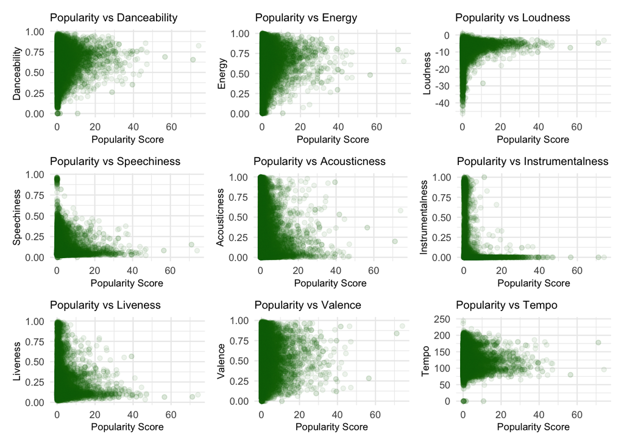

```r
# Define the song features to plot
song_features <- c("Danceability", "Energy", "Loudness", "Speechiness",
                   "Acousticness", "Instrumentalness", "Liveness", "Valence", "Tempo")

# Create a list to store individual plots
plot_list <- list()

# Loop through each feature and create a scatterplot
for (i in seq_along(song_features)) {
  feature <- song_features[i]
  p <- ggplot(clean_spotify_df, aes(x = popularity_score, y = .data[[feature]])) +
    geom_point(alpha = 0.08, color = "darkgreen") +
    labs(title = paste("Popularity vs", feature), x = "Popularity Score", y = feature) +
    theme_minimal(base_size = 10) +  # Reduce overall font size
    theme(plot.title = element_text(size = 9),  # Adjust title font size
          axis.title = element_text(size = 8),  # Adjust axis labels
          axis.text = element_text(size = 8))   # Adjust axis tick labels
  plot_list[[i]] <- p
}

# Combine the plots into a 3x3 grid using patchwork
combined_plots <- (plot_list[[1]] | plot_list[[2]] | plot_list[[3]]) /
                  (plot_list[[4]] | plot_list[[5]] | plot_list[[6]]) /
                  (plot_list[[7]] | plot_list[[8]] | plot_list[[9]])

# Increase the plot size
options(repr.plot.width = 15, repr.plot.height = 12)

# Display the combined plot
combined_plots
```

From the plots above we can start to address the first hypothesis:

*Hypothesis 1:*

- *Songs with higher **valence** (positive/happy tone) will be more popular.*
- *Songs with higher **danceability** and **energy** will have more streams and views.*
- *Songs with a moderate **tempo** (neither too fast nor too slow) will be more popular.*

Valence is essentially **a measure of how positive or negative a song is**. It’s a way to describe the emotional impact of a song. The closer to 1 the valence is, the more happy, cheerful, euphoric the song is.  
From the bottom middle plot we can see that the points are spread and mainly clustered across the **valence** axis (0 to 1)

This suggests that **valence alone is not a strong predictor of popularity**, as both high and low valence songs can be unpopular and popular. Ultimately the following claim disproves my original hypothesis of “Songs with higher **valence** (positive/happy tone) will be more popular”.

**Hypothesis 2:**  
Songs with official videos will have significantly more views and streams (and thus higher popularity_score).

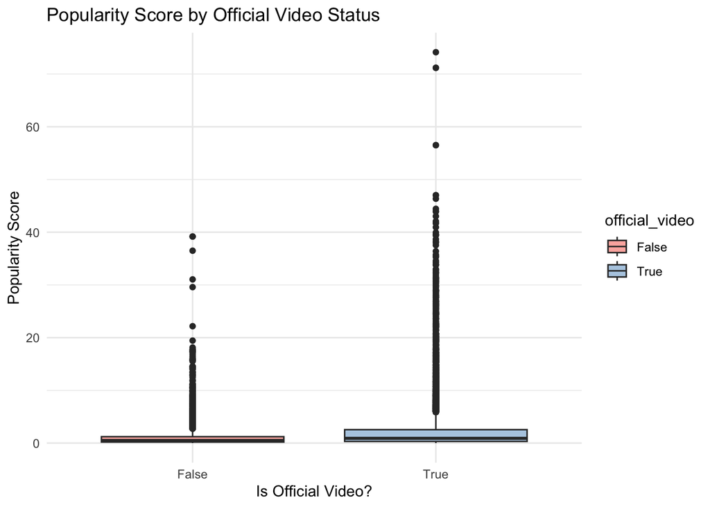

```r
# Boxplot comparing popularity score by official video status
ggplot(clean_spotify_df, aes(x = official_video, y = popularity_score, fill = official_video)) +
  geom_boxplot() +
  labs(title = "Popularity Score by Official Video Status",
       x = "Is Official Video?",
       y = "Popularity Score") +
  theme_minimal() +
  scale_fill_brewer(palette="Pastel1")
```

```r
# Perform t-test (Welch's t-test is default, good if variances are unequal)
t_test_official <- t.test(popularity_score ~ official_video, data = clean_spotify_df)
print(t_test_official)
```

```
    Welch Two Sample t-test

data:  popularity_score by official_video
t = -26.596, df = 14494, p-value < 2.2e-16
alternative hypothesis: true difference in means between group False and group True is not equal to 0
95 percent confidence interval:
 -1.423166 -1.227789
sample estimates:
mean in group False  mean in group True
           1.153143            2.478620
```

Because the P-value is below 0.05, we can reject the null hypothesis (that there’s no difference in means) and conclude there’s a statistically significant difference in popularity_score between official and non-official videos. The mean in group FALSE and mean in group TRUE show the direction – official videos likely have a much higher mean score.

This makes a lot of sense considering that, official videos usually signify a higher investment from the artist/label, are promoted more, and are the primary destination for fans seeking the canonical version of the song’s visual representation. Finding a significant difference strongly supports this hypothesis.

*Hypothesis 3:*

*Singles will have more streams and views compared to songs released as part of an album.*

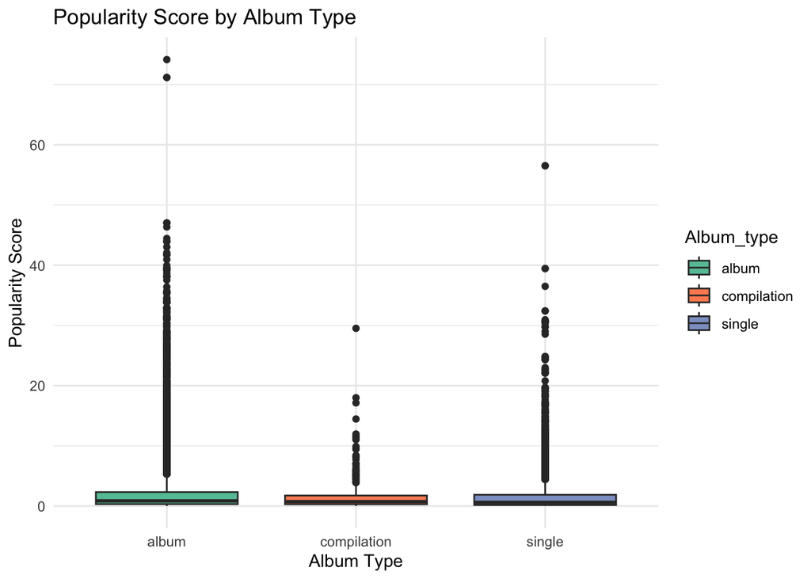

```r
ggplot(clean_spotify_df, aes(x = Album_type, y = popularity_score, fill = Album_type)) +
  geom_boxplot() +
  labs(title = "Popularity Score by Album Type",
       x = "Album Type",
       y = "Popularity Score") +
  theme_minimal() +
  scale_fill_brewer(palette="Set2")
```

```r
# If only two types ('album', 'single'), proceed with t-test
if(length(unique(clean_spotify_df$Album_type)) == 2) {
  t_test_album <- t.test(popularity_score ~ Album_type, data = clean_spotify_df)
  print(t_test_album)
} else {
  # If more than two types, use ANOVA
  aov_album <- aov(popularity_score ~ Album_type, data = clean_spotify_df)
  summary(aov_album)
}
```

```
               Df Sum Sq Mean Sq F value Pr(>F)
Album_type      2   1577   788.4   45.91 <2e-16 ***
Residuals   19546 335664    17.2
---
Signif. codes:  0 '***' 0.001 '**' 0.01 '*' 0.05 '.' 0.1 ' ' 1
```

The ANOVA results strongly suggest that the album type has a significant impact on the popularity score (streams and views). From the box plot it becomes more clear that that albums garner more “popularity”. The reason for why this might be is because tracks from highly anticipated albums tend to create a sense of “hype” which translates to more views and streams.

## Cluster Analysis

Let’s group songs based on their audio features to see if distinct “types” of songs emerge and if these types differ in popularity.

We’ll use the main audio features. Scaling is crucial because features are on different scales (e.g., Tempo vs. Danceability).

```r
library(factoextra)
# Select numerical audio features
audio_features_df <- clean_spotify_df %>%
  select(Danceability, Energy, Loudness, Speechiness, Acousticness,
         Instrumentalness, Liveness, Valence, Tempo)

# Scale the features (center to mean 0, scale to standard deviation 1)
scaled_audio_features <- scale(audio_features_df)

# Check the first few rows of scaled data
head(scaled_audio_features)
```

```
  Danceability    Energy   Loudness Speechiness Acousticness Instrumentalness
1    1.1900551 0.3269891  0.2065841   0.7681220   -0.9819437      -0.27510147
2    0.3319907 0.3176238  0.3936441  -0.6136123   -0.7072404      -0.28363570
3    0.4468022 1.3478057  0.8017552  -0.4065404   -0.8625349      -0.04359172
4    0.4105459 0.4861990  0.3947266  -0.6531442   -1.0111310       2.35669221
5    0.2534356 0.2754800 -0.2151669   0.7116478   -0.9226940      -0.28720418
6    0.8395781 1.1979610  0.3856334  -0.5477258   -0.9310883       0.16418010
    Liveness     Valence        Tempo
1  2.5531529  0.99111722  0.606134290
2 -0.8772943  1.31734418 -0.940085169
3 -0.4553741  0.08991525 -0.425117585
4 -0.7701495  0.20001685 -0.006168346
5 -0.7350400 -0.01610851  1.598526420
6  0.6463400  1.78221760 -0.011536460
```

```r
# Set seed for reproducibility
set.seed(123)

# Choose k
k_chosen <- 4
kmeans_result <- kmeans(scaled_audio_features, centers = k_chosen, nstart = 25) # nstart runs algorithm multiple times

# Add cluster assignments back to the original dataframe
clean_spotify_df$cluster <- as.factor(kmeans_result$cluster)
```

```r
# Calculate mean feature values for each cluster
cluster_summary <- clean_spotify_df %>%
  group_by(cluster) %>%
  summarise(across(c(Danceability, Energy, Loudness, Speechiness, Acousticness,
                     Instrumentalness, Liveness, Valence, Tempo, popularity_score), mean, na.rm = TRUE),
            count = n()) %>%
  arrange(desc(popularity_score)) # Order by mean popularity
print(cluster_summary)
```

```
# A tibble: 4 × 12
  cluster Danceability Energy Loudness Speechiness Acousticness Instrumentalness
  <fct>          <dbl>  <dbl>    <dbl>       <dbl>        <dbl>            <dbl>
1 4              0.651  0.748    -5.83      0.0663        0.152          0.0283
2 1              0.723  0.654    -6.89      0.313         0.228          0.00723
3 3              0.541  0.428    -9.90      0.0485        0.561          0.0178
4 2              0.328  0.195   -22.3       0.0460        0.824          0.819
# ℹ 5 more variables: Liveness <dbl>, Valence <dbl>, Tempo <dbl>,
#   popularity_score <dbl>, count <int>
```

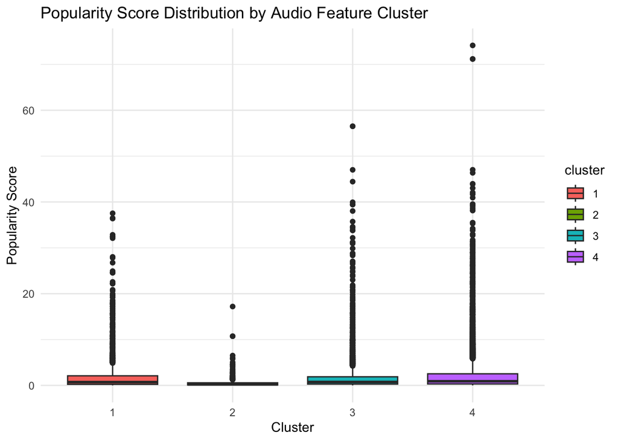

```r
# Visualize popularity score distribution across clusters
ggplot(clean_spotify_df, aes(x = cluster, y = popularity_score, fill = cluster)) +
  geom_boxplot() +
  labs(title = "Popularity Score Distribution by Audio Feature Cluster",
       x = "Cluster",
       y = "Popularity Score") +
  theme_minimal()
```

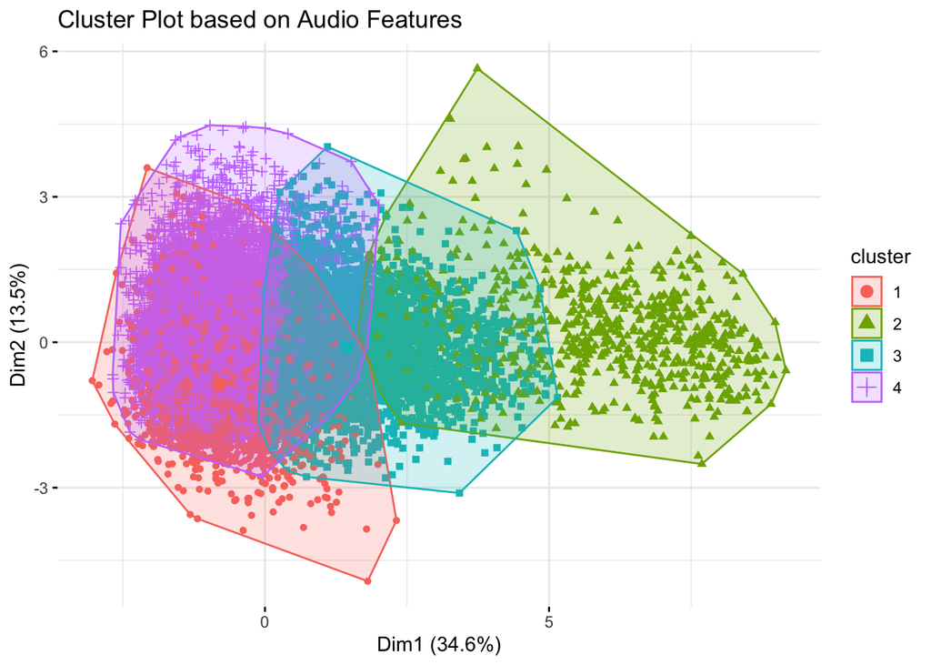

```r
# Visualize clusters using PCA (Principal Component Analysis) for dimensionality reduction
fviz_cluster(kmeans_result, data = scaled_audio_features,
             geom = "point",
             ellipse.type = "convex",
             ggtheme = theme_minimal(),
             main = "Cluster Plot based on Audio Features")
```

The table shows the average (mean) value for each audio feature and the average popularity_score within each cluster, as well as the number of songs (count) in each cluster. The clusters are ordered by their average popularity_score from highest to lowest.

Here’s an interpretation of each cluster:

**Cluster 4: The Mainstream Energetic Hits**

- **Popularity Score:** 2.48 (Highest)
- **Size:** 11,319 songs (Largest Cluster - ~50% of the data)
- **Key Characteristics:**
  - **High Energy (0.75) & High Loudness (-5.8 dB):** These are energetic, loud tracks, typical of modern production.
  - **Low Acousticness (0.15) & Low Instrumentalness (0.03):** Predominantly non-acoustic (electronic, amplified) with strong vocal presence.
  - **Moderate-High Danceability (0.65) & Moderate-High Valence (0.61):** Generally upbeat, positive, and suitable for dancing.
  - **Low Speechiness (0.07):** Primarily melodic music, not spoken word focused.
  - **Moderate Tempo (123 BPM):** A common tempo range for pop and dance music.
- **Interpretation:** This cluster represents the bulk of the songs in the dataset and also the most popular group on average. These are likely mainstream Pop, EDM, upbeat Hip-Hop/R&B, or Rock songs. Their characteristics (high energy, loudness, danceability, vocals, positive feel) align well with what often performs well commercially.

**Cluster 1: The High-Speechiness / Rap & Hip-Hop Contenders**

- **Popularity Score:** 2.04 (Second Highest)
- **Size:** 2,713 songs (Moderate Size)
- **Key Characteristics:**
  - **Very High Speechiness (0.31):** This is the defining feature. Values above 0.33 start indicating spoken word presence.
  - **High Danceability (0.72):** Even more danceable than Cluster 4.
  - **Moderate-High Energy (0.65) & Loudness (-6.9 dB):** Still energetic and relatively loud.
  - **Very Low Instrumentalness (0.007):** Extremely vocal-centric.
  - **Moderate Valence (0.56) & Tempo (122.5 BPM):** Reasonably positive and similar tempo to Cluster 4.
  - **Low-Moderate Acousticness (0.23):** Mostly non-acoustic production.
- **Interpretation:** This cluster is also quite popular. The very high speechiness strongly suggests this group is dominated by **Hip-Hop, Rap**, and potentially R&B tracks with significant rap verses or spoken sections. They are highly danceable and energetic, contributing to their popularity.

**Cluster 3: The Acoustic & Mellow / Ballads & Folk**

- **Popularity Score:** 1.86 (Third Highest)
- **Size:** 4,715 songs (Second Largest Cluster)
- **Key Characteristics:**
  - **High Acousticness (0.56):** A defining feature. Significantly more acoustic than clusters 4 and 1.
  - **Low Energy (0.43) & Moderate-Low Loudness (-9.9 dB):** Much quieter and less intense.
  - **Moderate-Low Danceability (0.54):** Less suited for dancing.
  - **Lower Valence (0.39):** Tending towards neutral, sad, or calm moods rather than overtly happy.
  - **Low Speechiness (0.05) & Low Instrumentalness (0.02):** Still primarily vocal music.
  - **Moderate Tempo (115.5 BPM):** Slightly slower on average than the top clusters.
- **Interpretation:** This large cluster represents songs with significantly lower average popularity than the first two. The high acousticness, low energy, and lower valence profile points towards **Ballads, Folk music, Singer-Songwriter tracks**, or slower, more subdued Pop/Rock songs. While still mostly vocal, they lack the high energy and loudness of the most popular clusters.

**Cluster 2: The Ambient & Instrumental Niche**

- **Popularity Score:** 0.54 (Lowest by far)
- **Size:** 802 songs (Smallest Cluster)
- **Key Characteristics:**
  - **Very High Instrumentalness (0.82):** Defining feature. These tracks are mostly or entirely instrumental.
  - **Very High Acousticness (0.82):** Also defining. Very likely acoustic instruments.
  - **Very Low Energy (0.19), Very Low Loudness (-22.3 dB), Very Low Danceability (0.33):** Extremely quiet, calm, and not for dancing.
  - **Very Low Valence (0.17):** Suggests very calm, ambient, possibly melancholic or background moods.
  - **Low Speechiness (0.05):** Confirms lack of vocals.
  - **Slower Tempo (104 BPM):** Slowest average tempo.
- **Interpretation:** This is the smallest and least popular cluster by a significant margin. The combination of extremely high instrumentalness and acousticness, along with very low energy, loudness, and valence, clearly identifies this group as likely **Ambient music, Classical pieces, very sparse Instrumental Folk, or potentially background/study music**. These are typically niche genres with lower stream/view counts compared to mainstream vocal music.

## Machine Learning

Now that we have a good understanding of the components and combinations of features that make a popular song, we can attempt to create a predictive model using machine learning algorithms.

For the sake of this project we will be attempting to make a ML model that can predict the number of streams a song will get based on the songs features (“Danceability”, “Energy”, “Key”, “Loudness”,etc.)

### Prepare the Data

First lets import the libraries needed for machine learning

```r
# Load necessary libraries
library(dplyr)         # For data manipulation
library(caret)         # For data splitting and potentially model tuning/evaluation
library(randomForest)  # For the Random Forest model
library(Metrics)       # For evaluation metrics like rmse, mae
library(ggplot2)       # For plotting feature importance
```

We select the required columns and convert the Key variable into a factor, as it represents distinct categories rather than a continuous numerical scale.

```r
# Select predictor features and target variable
features_for_model <- c("Danceability", "Energy", "Key", "Loudness", "Speechiness",
                        "Acousticness", "Instrumentalness", "Liveness", "Valence",
                        "Tempo", "Duration_ms")
target_variable <- "Stream"

# Create the dataset for modeling
model_df <- clean_spotify_df %>%
  select(all_of(features_for_model), all_of(target_variable)) %>%
  mutate(Key = as.factor(Key)) # Treat Key as a categorical variable

# Check the structure
str(model_df)
```

```
'data.frame':   19549 obs. of  12 variables:
 $ Danceability    : num  0.818 0.676 0.695 0.689 0.663 0.76 0.716 0.726 0.741 0.625 ...
 $ Energy          : num  0.705 0.703 0.923 0.739 0.694 0.891 0.897 0.815 0.913 0.877 ...
 $ Key             : Factor w/ 12 levels "0","1","2","3",..: 7 9 2 3 11 12 5 12 3 11 ...
 $ Loudness        : num  -6.68 -5.82 -3.93 -5.81 -8.63 ...
 $ Speechiness     : num  0.177 0.0302 0.0522 0.026 0.171 0.0372 0.0629 0.0313 0.0465 0.162 ...
 $ Acousticness    : num  8.36e-03 8.69e-02 4.25e-02 1.51e-05 2.53e-02 2.29e-02 1.20e-02 7.99e-03 3.43e-03 3.15e-02 ...
 $ Instrumentalness: num  0.00233 0.000687 0.0469 0.509 0 0.0869 0.262 0.081 0.103 0.0811 ...
 $ Liveness        : num  0.613 0.0463 0.116 0.064 0.0698 0.298 0.325 0.112 0.325 0.672 ...
 $ Valence         : num  0.772 0.852 0.551 0.578 0.525 0.966 0.358 0.462 0.643 0.865 ...
 $ Tempo           : num  138.6 92.8 108 120.4 168 ...
 $ Duration_ms     : num  222640 200173 215150 233867 340920 ...
 $ Stream          : num  1.04e+09 3.10e+08 6.31e+07 4.35e+08 6.17e+08 ...
 - attr(*, "na.action")= 'omit' Named int [1:1169] 31 32 33 35 36 37 39 219 240 411 ...
  ..- attr(*, "names")= chr [1:1169] "31" "32" "33" "35" ...
```

```r
# Optional: Check for remaining NAs (should be none if na.omit was comprehensive)
```

### Split Data into Training and Testing Sets

We’ll split the data (e.g., 75% for training, 25% for testing) to evaluate how well the model generalizes to new, unseen data. We set a seed for reproducibility.

```r
set.seed(42) # for reproducible results

# Create indices for the training set
train_indices <- createDataPartition(model_df$Stream, p = 0.75, list = FALSE)

# Create training and testing sets
train_data <- model_df[train_indices, ]
test_data <- model_df[-train_indices, ]

# Check dimensions
dim(train_data)
```

```
[1] 14663    12
```

```r
dim(test_data)
```

```
[1] 4886   12
```

### Train the Random Forest Model

We train the Random Forest model using the training data. We include importance=TRUE to calculate feature importance scores later.

```r
# Set seed again just before training for reproducibility of the model itself
set.seed(42)

# Train the Random Forest model

rf_model <- randomForest(Stream ~ .,
                         data = train_data,
                         ntree = 500,       # Number of trees (default is often 500)
                         importance = TRUE, # Calculate feature importance
                         na.action = na.omit) # Handle potential NAs missed earlier

# Print model summary (shows type, ntree, mtry, OOB error)
print(rf_model)
```

```
Call:
 randomForest(formula = Stream ~ ., data = train_data, ntree = 500,      importance = TRUE, na.action = na.omit)
               Type of random forest: regression
                     Number of trees: 500
No. of variables tried at each split: 3

          Mean of squared residuals: 4.927684e+16
                    % Var explained: 18.99
```

### Make Predictions on the Test Set

```r
# Predict on the test set
predictions <- predict(rf_model, newdata = test_data)

# Combine actuals and predictions for easier comparison/plotting (optional)
results_df <- data.frame(Actual = test_data$Stream,
                         Predicted = predictions)

head(results_df)
```

```
       Actual Predicted
6   323850327 129142968
10  191074713 163358734
17  550067391 227909479
21 1041736808 212951178
24  541728561 289658240
26  202477187 186120340
```

### Evaluate Model Performance

```r
# Calculate evaluation metrics
rmse_value <- rmse(actual = test_data$Stream, predicted = predictions)
mae_value <- mae(actual = test_data$Stream, predicted = predictions)

# Calculate R-squared for the test set predictions
# Note: This is the squared correlation between actual and predicted values
# It's a common way to report R-squared for test set performance
rsquared_value <- cor(test_data$Stream, predictions)^2
# Alternatively, using caret's R2 function:
# rsquared_value_caret <- R2(pred = predictions, obs = test_data$popularity_score)


cat("Evaluation Metrics on Test Set:\n")
```

```
Evaluation Metrics on Test Set:
```

```r
cat("---------------------------------\n")
cat("RMSE (Root Mean Squared Error):", round(rmse_value, 4), "\n")
```

```
RMSE (Root Mean Squared Error): 220986616
```

```r
cat("MAE (Mean Absolute Error):     ", round(mae_value, 4), "\n")
```

```
MAE (Mean Absolute Error):      129069674
```

```r
cat("R-squared:                    ", round(rsquared_value, 4), "\n")
```

```
R-squared:                     0.2047
```

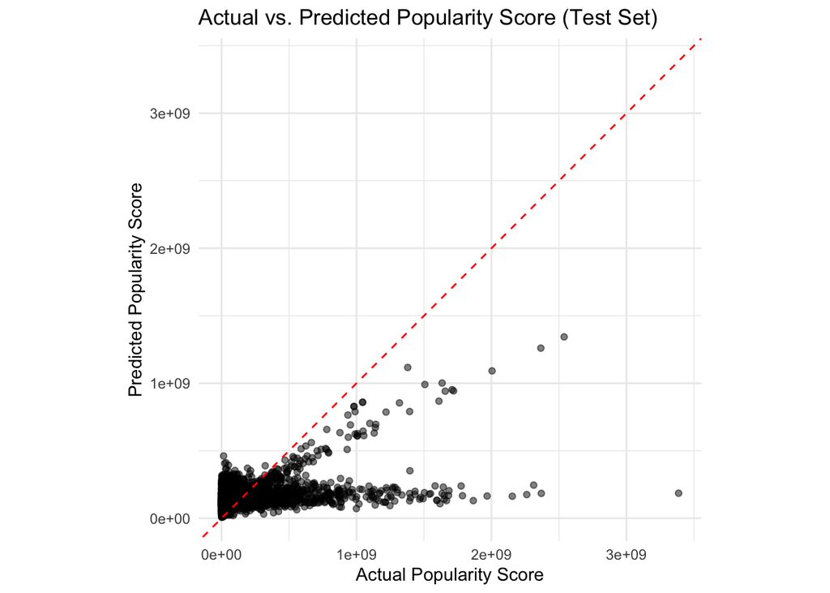

```r
# Optional: Plot Actual vs Predicted
ggplot(results_df, aes(x = Actual, y = Predicted)) +
  geom_point(alpha = 0.5) +
  geom_abline(intercept = 0, slope = 1, color = "red", linetype = "dashed") + # Line y=x
  labs(title = "Actual vs. Predicted Popularity Score (Test Set)",
       x = "Actual Popularity Score",
       y = "Predicted Popularity Score") +
  theme_minimal() +
  coord_fixed(ratio = 1, xlim = range(results_df$Actual, results_df$Predicted), ylim = range(results_df$Actual, results_df$Predicted)) # Ensure axes have same scale
```

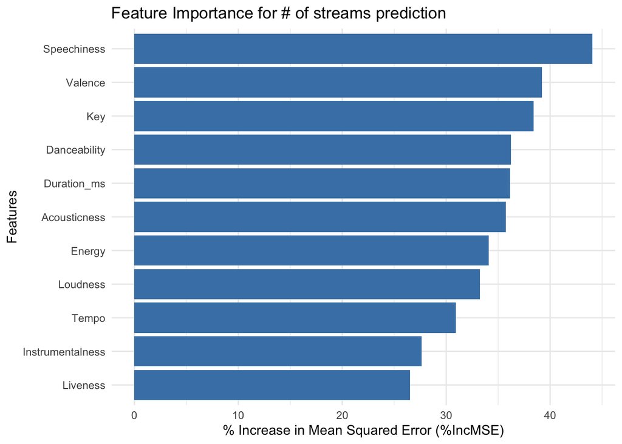

```r
# Get feature importance
importance_scores <- importance(rf_model)

# Create a data frame for plotting
importance_df <- data.frame(
  Feature = rownames(importance_scores),
  Importance = importance_scores[, "%IncMSE"]
) %>%
  arrange(desc(Importance)) # Order by importance

# Plot feature importance
ggplot(importance_df, aes(x = reorder(Feature, Importance), y = Importance)) +
  geom_bar(stat = "identity", fill = "steelblue") +
  coord_flip() + # Flip coordinates for horizontal bars
  labs(title = "Feature Importance for # of streams prediction",
       x = "Features",
       y = "% Increase in Mean Squared Error (%IncMSE)") +
  theme_minimal()
```

```r
# Print the importance data frame
print(importance_df)
```

```
                          Feature Importance
Speechiness           Speechiness   44.06171
Valence                   Valence   39.20140
Key                           Key   38.41805
Danceability         Danceability   36.24115
Duration_ms           Duration_ms   36.14803
Acousticness         Acousticness   35.74868
Energy                     Energy   34.10392
Loudness                 Loudness   33.22483
Tempo                       Tempo   30.95014
Instrumentalness Instrumentalness   27.64239
Liveness                 Liveness   26.53746
```

## Overall Conclusions:

To improve this study the data set could also be changed to include all of the music made in a certain year then comparing the streams or views between those songs using the same song component variables to accurately develop a model.

However, there are certain factors and relations that were found in this project that can give insight into what makes the most songs:

Do these results make sense?:

Yes, The findings largely align with intuition and industry knowledge:

- Higher energy and loudness are common in popular music charts.
- Acoustic or highly instrumental tracks are often more niche than mainstream vocal pop/rock/electronic tracks.
- Official videos are crucial for promotion and engagement.
- The difficulty in perfectly predicting popularity with just audio features makes sense – marketing, artist fame, timing, trends, and subjective taste play huge roles.
- The skewed distribution of popularity (“winner-takes-all” market) is realistic.